# Meeting 1: Word embeddings

What does geometry encode? · Technical clarifications

28 October 2026

## What the SGNS objective pushes up

Keep only the positive term (Goldberg & Levy, §2):

$$\max_\theta \sum_{(w,c)\in D} \log \sigma(v_c \cdot v_w)$$

- It rewards a large **inner product** for every observed pair:  
  length as much as direction.
- Without negatives there is **no finite optimum**:  
  e.g. make all $v_w = v_c$ (G&L’s construction) and scale them up ($v_c\cdot v_w \approx 40$ already gives $\sigma \approx 1$).
- Negative samples push sampled pairs apart.  
  They are random draws from $p(w)^{3/4}$, not known non-co-occurrences.

## What SGNS models

- Not $p(c \mid w)$: a **classifier** of real vs. sampled pairs, $p(D{=}1 \mid w, c)$.
- G&L §2.1: “a quantity related to the joint distribution”.  
  At the unconstrained optimum, $v_w\cdot v_c = \mathrm{PMI}(w,c) - \log k$  
  (Levy & Goldberg 2014; needs a large enough dimension;  
  with negatives from $p^{3/4}$, the context marginal in the PMI is the smoothed one).
- **Two vectors per word:** with a shared vector, $\sigma(\|v\|^2) \ge 1/2$,  
  so *dog* could never be unlikely as its own context.

## Mimno & Thompson: the findings

- All word vectors have a large positive inner product  
  with the mean vector (Fig. 2): a **narrow cone**
- Context vectors point the **opposite** way (Figs. 3, 5)
- The effect grows with the number of negative samples $S$ (Fig. 6)
- After flipping signs per dimension, the vectors are mostly non-negative
- GloVe on the same corpus: no single cone,  
  organised by word frequency instead
- t-SNE hides the word/context split (Fig. 1)

## The cone in our own SGNS model

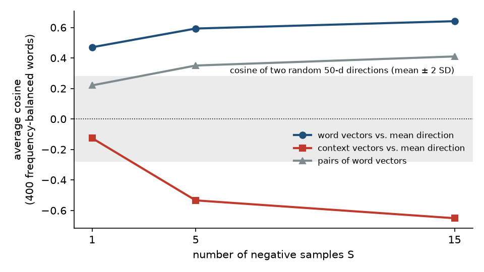

SGNS on text8, 50 dims · 400 words, 100 per M&T frequency band · one run per $S$ · cosines, not raw inner products  
$S = 5$: average pair cosine **0.35**, **99.8%** of pairs positive; random directions: **0 ± 0.14**  
Grey band: the range for *one* pair of random directions; the lines are averages over many pairs

## So: is a cosine of 0.3 high?

Between two random directions in 50 dimensions:  
about **2 standard deviations** above chance.

Between two words in this SGNS space:  
**below** the average pair (0.35).

**Compared to what?**  
This question comes back in Meetings 4–5:  
baselines and null calibration for similarity scores.

## The vector-offset method

$$y = \hat x_b - \hat x_a + \hat x_c, \qquad w^* = \arg\max_w \cos(x_w, y)$$

($\hat x$: vectors normalised to unit length)

Mikolov et al.: correct if $w^* = d$ · 39.6% on their syntactic test set (RNN, 1600 dims)  
Their only baseline (footnote 2):  
“Guessing gets a small fraction of a percent.”

Random guessing is the wrong baseline:  
it doesn’t show what the **offset** contributes.

## Baselines in our SGNS model

| Method | all | semantic | syntactic |
| --- | --- | --- | --- |
| offset, $a, b, c$ excluded | **30.0%** | 22.9% | 33.5% |
| offset, $a, b, c$ allowed | **15.3%** | 10.5% | 17.7% |
| $b + c$ (no $a$ in the query) | 10.5% | 12.2% | 9.7% |
| nearest neighbour of $c$ | **6.3%** | 4.0% | 7.4% |

Google analogy set (different test set, model and corpus: *not* comparable with 39.6%)  
All methods except “inputs allowed” exclude $a, b, c$ as answers; queries use unit-length vectors  
12,227 of 19,544 questions have all four words among the 30,000 most frequent words,  
which are the candidates for every method  
With inputs allowed, **66%** of answers are one of $a, b, c$

## By relation (6 of 14 relations)

| Relation | offset | nearest neighbour of $c$ |
| --- | --- | --- |
| opposite (*possible : impossible*) | 15.4% | **33.3%** |
| family (*boy : girl*) | 52.6% | 39.5% |
| present participle (*code : coding*) | 27.1% | 18.9% |
| plural (*banana : bananas*) | 32.9% | 15.6% |
| common-country capitals (*greece : athens*) | 40.7% | 0.0% |
| nationality adjective (*france : french*) | 60.0% | 0.0% |

“The offset method works” is a claim that differs relation by relation.

## Cosine, Euclidean distance, inner product

$$\|u - v\|^2 = \|u\|^2 + \|v\|^2 - 2\,\|u\|\,\|v\| \cos(u, v)$$

$$u \cdot v = \|u\|\,\|v\| \cos(u, v)$$

- Unit-length vectors: cosine and Euclidean distance rank neighbours **identically**.
- Raw vectors: the **norms** make them disagree.

|  | measure | raw or unit-length? |
| --- | --- | --- |
| SGNS objective (Goldberg & Levy) | inner product | raw |
| Mimno & Thompson, Figs. 2, 3, 5–8 | inner products (with the mean; Fig. 3: word–context pairs) | raw (normalised as a check) |
| Mikolov et al., offset method | cosine | unit-length |
| Euclidean distance | used by none of the three |  |

## Neighbours under the three measures

Our SGNS model, 300 mid-frequency words, 10 nearest neighbours under cosine.  
Top-10 overlap with cosine: Euclidean **70%** · inner product **22%**  
Inner-product neighbours are longer: typically **1.36×** the median norm of the cosine neighbours

|  | cosine | Euclidean | inner product |
| --- | --- | --- | --- |
| *red* | blue, yellow, white, black, green, purple | blue, white, yellow, black, green, purple | stripes, yellow, hoist, sox, blue, crescent |
| *physics* | electrodynamics, chemistry, electromagnetism, mechanics, quantum, einstein | electrodynamics, chemistry, electromagnetism, theoretical, mechanics, condensates | relativity, quantum, chemistry, mechanics, electromagnetic, electromagnetism |

(top 6 of 10 shown)

## Norm vs. frequency in our model

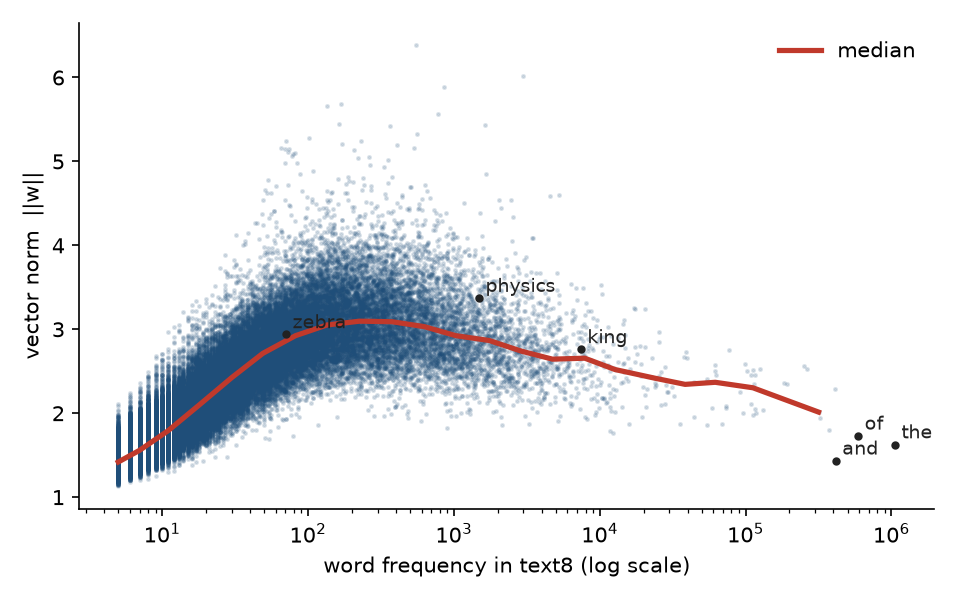

**Hump-shaped:** median norm 1.42 (seen 5×) → 3.10 (~225×) → 2.38 (top 100 words); *the*: 1.63.  
So the norm is related to frequency, but is not frequency, and not “importance”.  
Mimno & Thompson: “the inner product between vectors is used by the algorithm during training,  
but in practice vectors are often normalized to have unit length before use.”  
After normalising, the frequency-band order in their Fig. 2 changes.

## man : king :: woman : ?

| rank | $a, b, c$ allowed | $a, b, c$ excluded |
| --- | --- | --- |
| 1 | **king** (0.83) | pretender (0.80) |
| 2 | pretender (0.80) | matilda (0.80) |
| 3 | matilda (0.80) | emperor (0.80) |
| 4 | emperor (0.80) | sigismund (0.79) |
| 5 | sigismund (0.79) | empress (0.78) |
| 6 | empress (0.78) | **queen** (0.77) |

Cosine with $y$ in brackets  
Inputs excluded: *france : paris :: italy : ?* → venice (rome: rank 14)  
*car : cars :: apple : ?* → macintosh (apples: rank 617; text8 is Wikipedia)

## How parallel are the offsets?

Cosine between offsets $\hat x_b - \hat x_a$ (unit-length vectors) of the **same** relation  
(pairs that share a word left out):

| Relation | mean cosine of offsets |
| --- | --- |
| nationality adjective | 0.60 |
| capital cities (common countries) | 0.46 |
| plural | 0.29 |
| present participle | 0.20 |
| family | 0.19 |
| opposite | 0.10 |
| *offsets of different relations* | *0.00* |

The parallelogram is an approximation: well above 0, far from 1.

## Where shown, how general?

| Claim | Shown this week in |
| --- | --- |
| Word vectors occupy a narrow cone | SGNS (M&T; our demo) |
| Word and context vectors point in opposite directions | SGNS (M&T) |
| Relations correspond to (roughly) constant offsets | RNN language model (Mikolov); SGNS (demo) |
| Vector norm is related to frequency | SGNS (our demo): hump-shaped, not monotone; one run |

Cone, opposition and norm: shown for one objective (and one corpus).  
Offsets: beyond one objective, but approximate and relation-dependent.